# HW8-shiyuchen-21210980116

Shi Yuchen

5/17/2022

# NBA数据降维分析

数据文件为截至2019年NBA球员季后赛总得分和每个球员的比赛详细数据。该数据收集了2448条NBA职业篮球运动员的各项比赛数据，其中包含勒布朗·詹姆斯、迈克尔·乔丹、科比·布莱恩特等多位全能巨星球员的投篮、三分球、罚球、助攻、抢断次数和季后赛总得分等18个变量信息。详细的变量说明表如下所示：

| **变量名** | **详细说明** | **取值范围** |
| --- | --- | --- |
| **生涯总得分** | 连续变量 | 0-6911 |
| **球员** | 文本数据 | 每个球员的官方姓名 |
| **出场数** | 连续变量 | 1-259 |
| **上场总时间** | 连续变量 | 0-10059 |
| **投篮率** | 连续变量 | 0%-100% |
| **命中次数** | 连续变量 | 0-2457 |
| **出手次数** | 连续变量 | 0-5006 |
| **三分投球率** | 连续变量 | 0%-100% |
| **三分命中次数** | 连续变量 | 0-410 |
| **三分出手次数** | 连续变量 | 0-1116 |
| **罚球率** | 连续变量 | 0%-100% |
| **罚球命中次数** | 连续变量 | 0-1627 |
| **罚球出手次数** | 连续变量 | 0-2317 |
| **篮板数** | 连续变量 | 0-4104 |
| **助攻次数** | 连续变量 | 0-2346 |
| **抢断次数** | 连续变量 | 0-419 |
| **盖帽次数** | 连续变量 | 0-568 |
| **失误次数** | 连续变量 | 0-866 |
| **犯规次数** | 连续变量 | 0-797 |

分析任务： 1. 读入NBA数据集； 2. 对所有的自变量进行主成分分析，选择主成分个数时使用碎石图的方法，并对结果进行解读；（提示：可以使用princomp()函数或psych包的 principal()函数） 3. 根据任务2的结果，计算每一位球员的主成分得分，并挑选几位球员进行解读； 4. 对NBA球员进行K-means聚类，并对结果进行解读；

```r
library(ggplot2)
library(ggpubr)
library(tidyr)
library(dplyr)
library(corrplot)
library(psych)
library(readxl)
NBA <- read_excel("NBA.xlsx")
head(NBA)
```

```
## # A tibble: 6 × 19
##   球员  出场数 `上场总时间（m…` 投篮率 命中次数 出手次数 三分投球率 三分命中次数
##   <chr>  <dbl>            <dbl>  <dbl>    <dbl>    <dbl>      <dbl>        <dbl>
## 1 勒布…    239            10059  0.491     2457     5006      0.332          370
## 2 迈克…    179             7474  0.487     2188     4497      0.332          148
## 3 卡里…    237             8851  0.533     2356     4422      0                0
## 4 科比…    220             8635  0.448     2014     4499      0.331          292
## 5 沙奎…    216             8099  0.563     2041     3627      0                0
## 6 蒂姆…    251             9372  0.501     1975     3939      0.143            5
## # … with 11 more variables: 三分出手次数 <dbl>, 罚球率 <dbl>,
## #   罚球命中次数 <dbl>, 罚球出手次数 <dbl>, 篮板数 <dbl>, 助攻次数 <dbl>,
## #   抢断次数 <dbl>, 盖帽次数 <dbl>, 失误次数 <dbl>, 犯规次数 <dbl>,
## #   生涯总得分 <dbl>
```

```r
summary(NBA)
```

```
##      球员               出场数      上场总时间（min）     投篮率
##  Length:2448        Min.   :  1.0   Min.   :    0.0   Min.   :0.0000
##  Class :character   1st Qu.:  6.0   1st Qu.:   19.0   1st Qu.:0.3450
##  Mode  :character   Median : 16.0   Median :  193.0   Median :0.4210
##                     Mean   : 30.2   Mean   :  694.0   Mean   :0.3994
##                     3rd Qu.: 41.0   3rd Qu.:  841.5   3rd Qu.:0.4760
##                     Max.   :259.0   Max.   :10059.0   Max.   :1.0000
##     命中次数         出手次数        三分投球率      三分命中次数
##  Min.   :   0.0   Min.   :   0.0   Min.   :0.0000   Min.   :  0.00
##  1st Qu.:   5.0   1st Qu.:  14.0   1st Qu.:0.0000   1st Qu.:  0.00
##  Median :  31.0   Median :  74.0   Median :0.0000   Median :  0.00
##  Mean   : 113.5   Mean   : 255.0   Mean   :0.1313   Mean   : 11.23
##  3rd Qu.: 122.0   3rd Qu.: 287.2   3rd Qu.:0.3020   3rd Qu.:  4.00
##  Max.   :2457.0   Max.   :5006.0   Max.   :1.0000   Max.   :410.00
##   三分出手次数         罚球率        罚球命中次数      罚球出手次数
##  Min.   :   0.00   Min.   :0.0000   Min.   :   0.00   Min.   :   0.00
##  1st Qu.:   0.00   1st Qu.:0.5000   1st Qu.:   3.00   1st Qu.:   4.00
##  Median :   0.00   Median :0.7140   Median :  16.00   Median :  23.00
##  Mean   :  32.45   Mean   :0.6174   Mean   :  64.78   Mean   :  86.75
##  3rd Qu.:  14.00   3rd Qu.:0.8030   3rd Qu.:  65.00   3rd Qu.:  89.00
##  Max.   :1116.00   Max.   :1.0000   Max.   :1627.00   Max.   :2317.00
##      篮板数          助攻次数          抢断次数         盖帽次数
##  Min.   :   0.0   Min.   :   0.00   Min.   :  0.00   Min.   :  0.00
##  1st Qu.:   4.0   1st Qu.:   2.00   1st Qu.:  0.00   1st Qu.:  0.00
##  Median :  32.0   Median :  14.00   Median :  2.00   Median :  1.00
##  Mean   : 129.1   Mean   :  65.31   Mean   : 17.55   Mean   : 11.96
##  3rd Qu.: 133.0   3rd Qu.:  63.00   3rd Qu.: 18.00   3rd Qu.:  8.00
##  Max.   :4104.0   Max.   :2346.00   Max.   :419.00   Max.   :568.00
##     失误次数         犯规次数        生涯总得分
##  Min.   :  0.00   Min.   :  0.00   Min.   :   0.0
##  1st Qu.:  0.00   1st Qu.:  6.00   1st Qu.:  13.0
##  Median :  3.00   Median : 32.00   Median :  82.0
##  Mean   : 29.36   Mean   : 73.83   Mean   : 303.2
##  3rd Qu.: 27.00   3rd Qu.: 96.00   3rd Qu.: 325.2
##  Max.   :866.00   Max.   :797.00   Max.   :6911.0
```

## 主成分分析

```r
data <- NBA
data.pca = apply(NBA[,-c(1, 19)], 2, as.numeric)

# 计算相关系数矩阵
# r <- cor(data.pca)
# par(family = "SimHei") # ~/Library/Fonts
# 相关性矩阵可视化
# corrplot::corrplot(r, tl.col = "black", tl.cex = 0.6)
```

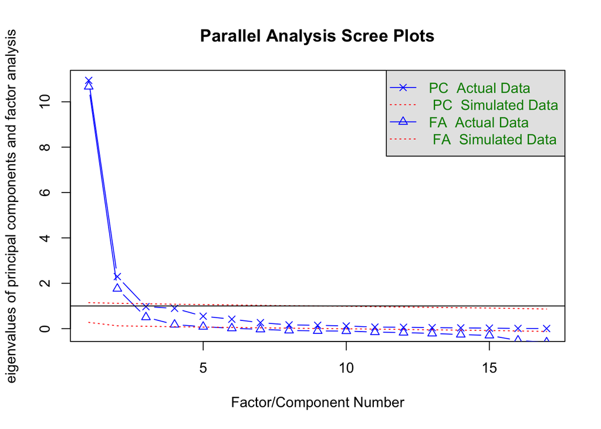

```
## Parallel analysis suggests that the number of factors =  5  and the number of components =  2
```

```r
# 先进行对数变换
data.pca = apply(data.pca, 2, function(x) log10(x+1))
# 归一化
data.pca.r = cor(data.pca)

psych::fa.parallel(data.pca.r, n.obs = nrow(data), fa = "both", n.iter = 100)
```

根据崖底碎石图, 选择主成分个数为2.

```r
pca <- princomp(data.pca, cor=T)
# summary(pca)
pca$sdev[1:5]^2 / sum( pca$sdev^2)
```

```
##     Comp.1     Comp.2     Comp.3     Comp.4     Comp.5
## 0.64373082 0.13497986 0.05700226 0.05270139 0.03220377
```

```r
pca$loadings[, 1:2]
```

```
##                      Comp.1       Comp.2
## 出场数            0.2803348  0.125064630
## 上场总时间（min） 0.2610480 -0.002401744
## 投篮率            0.1261164  0.055028606
## 命中次数          0.2876502  0.149834892
## 出手次数          0.2842055  0.158185156
## 三分投球率        0.1217690 -0.482166878
## 三分命中次数      0.1920750 -0.450863629
## 三分出手次数      0.1966607 -0.457763785
## 罚球率            0.1838599  0.137822830
## 罚球命中次数      0.2771617  0.197234445
## 罚球出手次数      0.2756699  0.210697046
## 篮板数            0.2686227  0.080357361
## 助攻次数          0.2751855  0.119420841
## 抢断次数          0.2523865 -0.204095397
## 盖帽次数          0.2302070 -0.103003215
## 失误次数          0.2345947 -0.276281153
## 犯规次数          0.2778825  0.192189943
```

```r
# eigen(data.pca.r)
```

从前两个 PC 的loading上来看, 第一个成分在各项指标上的分数都较大且较为均衡, 因此可以看作是衡量球员的「综合能力」; 第二个成分在命中、出手次数、罚球相关指标上数值较大, 而在三分相关的数值以及抢断、盖帽次数上有明显的负值, 可见更为注重速度进攻的能力, 可看作是「进攻指标」.

```r
data$PCA1 <- pca$scores[, 1]
data$PCA2 <- pca$scores[, 2]
```

从数据中筛选相关球员, 分析他们的两个主成分, 可见:

- 这些著名球员的第一个主成分分数就较高, 说明他们的职业能力都较强;
- 而就第二个主成分来看, 蒂姆-邓肯, 卡尔-马龙 等著名大前锋的数值较高.

```r
data[which(data$球员 %in%c("勒布朗-詹姆斯", "迈克尔-乔丹", "科比-布莱恩特",
                         "蒂姆-邓肯", "卡尔-马龙")), ]
```

```
## # A tibble: 5 × 21
##   球员  出场数 `上场总时间（m…` 投篮率 命中次数 出手次数 三分投球率 三分命中次数
##   <chr>  <dbl>            <dbl>  <dbl>    <dbl>    <dbl>      <dbl>        <dbl>
## 1 勒布…    239            10059  0.491     2457     5006      0.332          370
## 2 迈克…    179             7474  0.487     2188     4497      0.332          148
## 3 科比…    220             8635  0.448     2014     4499      0.331          292
## 4 蒂姆…    251             9372  0.501     1975     3939      0.143            5
## 5 卡尔…    193             7907  0.463     1743     3768      0.162            6
## # … with 13 more variables: 三分出手次数 <dbl>, 罚球率 <dbl>,
## #   罚球命中次数 <dbl>, 罚球出手次数 <dbl>, 篮板数 <dbl>, 助攻次数 <dbl>,
## #   抢断次数 <dbl>, 盖帽次数 <dbl>, 失误次数 <dbl>, 犯规次数 <dbl>,
## #   生涯总得分 <dbl>, PCA1 <dbl>, PCA2 <dbl>
```

## K-means聚类

```r
# 采用经过 log 变换后的原始指标进行聚类
data.kmeans <- data.pca
kmeans.fit <- kmeans(data.kmeans, 5)
data$cluster <- kmeans.fit$cluster
```

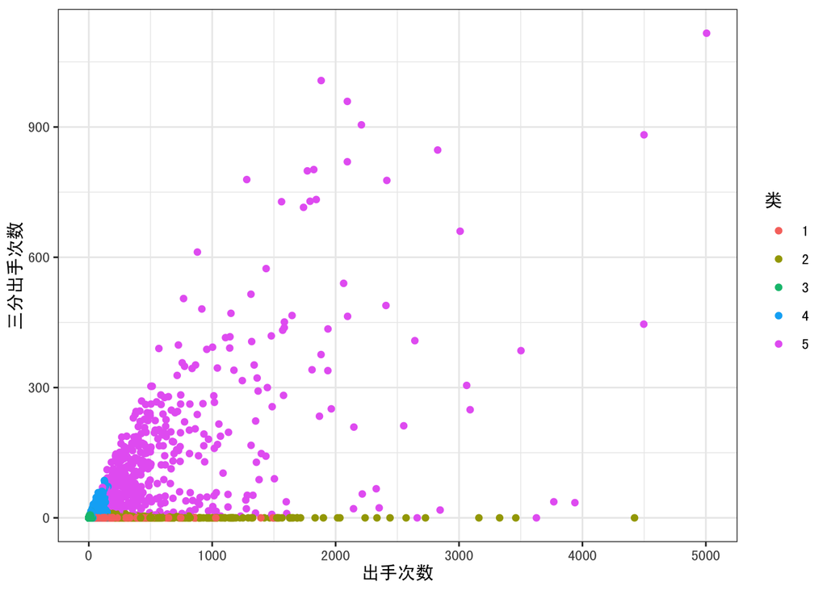

```r
data %>% ggplot() +
  geom_point(aes(x=出手次数, y=三分出手次数, color=as.factor(cluster))) +
  theme_bw() + theme(text = element_text(family = "SimHei")) + labs(color = "类")
```

以 出手次数, 三分出手次数 两个纬度来看聚类结果, 可以看到不同类的球员在这两个指标上有着较大的差异.

下面画出不同类在两个主成分上的分布情况. 注意到, 在聚类是并未采用这两个值, 但是聚类可以很好地在这两个纬度上进行区分, 体现了PCA的纬度压缩能力.

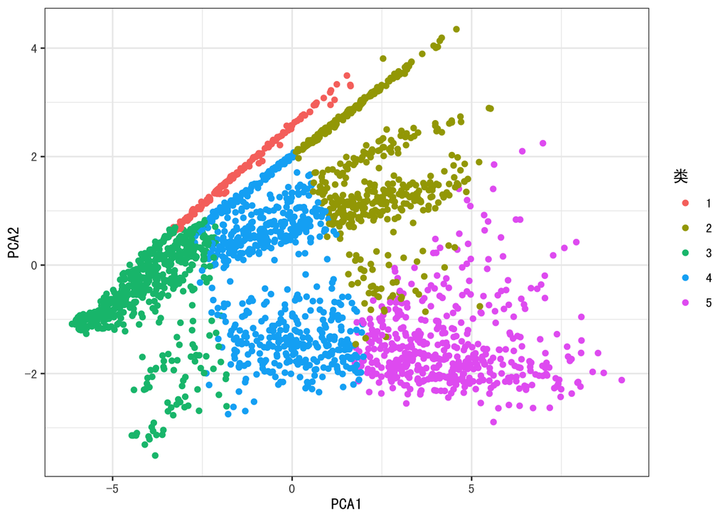

```r
data %>% ggplot() +
  geom_point(aes(x=PCA1, y=PCA2, color=as.factor(cluster))) +
  theme_bw() + theme(text = element_text(family = "SimHei")) + labs(color = "类")
```

从聚类结果上来看, 类别2和5是总得分较高的两个类别. 下面展示了两类球员在各项指标上的差异, 可以看到, 他们在抢断、盖帽、失误次数, 以及三分相关指标上存在着明显的差异.

```r
data[which(data$cluster==2),]
```

```
## # A tibble: 500 × 22
##    球员            出场数 `上场总时间（min…` 投篮率 命中次数 出手次数 三分投球率
##    <chr>            <dbl>              <dbl>  <dbl>    <dbl>    <dbl>      <dbl>
##  1 卡里姆-贾巴尔      237               8851  0.533     2356     4422          0
##  2 杰里-韦斯特        153               6321  0.469     1622     3460          0
##  3 约翰-哈福利切克    172               6860  0.436     1451     3329          0
##  4 埃尔金·贝勒        134               5510  0.439     1388     3161          0
##  5 威尔特-张伯伦      160               7559  0.522     1425     2728          0
##  6 朱利叶斯-欧文      141               5288  0.486     1187     2441          0
##  7 萨姆-琼斯          154               4654  0.447     1149     2571          0
##  8 罗波特-帕里什      184               6177  0.506     1132     2239          0
##  9 比尔-拉塞尔        165               7497  0.43      1003     2335          0
## 10 鲍勃-佩蒂特         88               3545  0.418      766     1834          0
## # … with 490 more rows, and 15 more variables: 三分命中次数 <dbl>,
## #   三分出手次数 <dbl>, 罚球率 <dbl>, 罚球命中次数 <dbl>, 罚球出手次数 <dbl>,
## #   篮板数 <dbl>, 助攻次数 <dbl>, 抢断次数 <dbl>, 盖帽次数 <dbl>,
## #   失误次数 <dbl>, 犯规次数 <dbl>, 生涯总得分 <dbl>, PCA1 <dbl>, PCA2 <dbl>,
## #   cluster <int>
```

```r
data[which(data$cluster==5),]
```

```
## # A tibble: 474 × 22
##    球员          出场数 `上场总时间（min）` 投篮率 命中次数 出手次数 三分投球率
##    <chr>          <dbl>               <dbl>  <dbl>    <dbl>    <dbl>      <dbl>
##  1 勒布朗-詹姆斯    239               10059  0.491     2457     5006      0.332
##  2 迈克尔-乔丹      179                7474  0.487     2188     4497      0.332
##  3 科比-布莱恩特    220                8635  0.448     2014     4499      0.331
##  4 沙奎尔-奥尼尔    216                8099  0.563     2041     3627      0
##  5 蒂姆-邓肯        251                9372  0.501     1975     3939      0.143
##  6 卡尔-马龙        193                7907  0.463     1743     3768      0.162
##  7 托尼-帕克        226                7766  0.461     1613     3502      0.309
##  8 凯文-杜兰特      136                5513  0.474     1340     2827      0.351
##  9 德维恩-韦德      177                6694  0.474     1450     3062      0.338
## 10 拉里·伯德        164                6886  0.472     1458     3090      0.321
## # … with 464 more rows, and 15 more variables: 三分命中次数 <dbl>,
## #   三分出手次数 <dbl>, 罚球率 <dbl>, 罚球命中次数 <dbl>, 罚球出手次数 <dbl>,
## #   篮板数 <dbl>, 助攻次数 <dbl>, 抢断次数 <dbl>, 盖帽次数 <dbl>,
## #   失误次数 <dbl>, 犯规次数 <dbl>, 生涯总得分 <dbl>, PCA1 <dbl>, PCA2 <dbl>,
## #   cluster <int>
```